# Measuring Similarities and Dissimilarities: Jaccard Index v Jaccard Distance

## Bibliography

1. Edward Marczewski, [Hugo Steinhaus](http://pldml.icm.edu.pl/pldml/search/page.action?qt=SEARCH&q=sc.general*l_0*c_0contributorId_0_0author_0eq.d87966277b076ee2c40ba6b3227b78de). (**Jaccard Distance and Index**). [On a certain distance of sets and the corresponding distance of functions](http://matwbn.icm.edu.pl/ksiazki/cm/cm6/cm6141.pdf). Colloquium Mathematicum (1958). Volume: 6, Issue: 1, page 319-327.
2. Marczewski, Edward (1907–1976), Steinhaus, Hugo (1887–1972). [O odległości systematycznej biotopów](http://pldml.icm.edu.pl/pldml/element/bwmeta1.element.desklight-656a99a1-2d53-438b-aa10-1d0a8be5bf13/c/zm4_3_01.pdf). Zastosowania Matematyki T.4 (1958-1959).
3. Sven Kosub. A note on the triangle inequality for the Jaccard distance. [rXiv:1612.02696](https://arxiv.org/abs/1612.02696).
4. Jeroen Bertels, Tom Eelbode, Maxim Berman, Dirk Vandermeulen, Frederik Maes, Raf Bisschops, Matthew Blaschko. Optimizing the Dice Score and Jaccard Index for Medical Image Segmentation: Theory & Practice. [rXiv:1911.01685](https://arxiv.org/abs/1911.01685).

The dice score formulation used in our UNet neural network is [see Milletari et al. page 6]:
$$\begin{align}
D_S(G,P)& = 2\cdot\frac{\sum_i g_ip_i}{\sum_i (g_i^2 + p_i^2)}&\text{Milletari et al.}\\
D_S(G,P)& = 2\cdot\frac{\sum_i g_ip_i}{\sum_i (g_i + p_i)}&\text{the standard definition}
\end{align}$$
where sum runs over all voxels, of the (manually segmented) ground truth binary volume $g_i∈G$ and the predicted binary segmentation volume $p_i∈P$.

„Using this formulation we do not need to assign weights to samples of different classes to establish the right balance between foreground and background voxels, and we obtain results that we experimentally observed are much better than the ones computed through the same network trained optimising a multinomial logistic loss with sample re-weighting.”

1. F. Milletari, N. Navab, and S.-A. Ahmadi. V-net: Fully convolutional neural networks for volumetric medical image segmentation. [rXiv:1606.04797](https://arxiv.org/abs/1606.04797) (2016).
2. Tomas Sakinis, Fausto Milletari, Holger Roth, Panagiotis Korfiatis, Petro Kostandy, Kenneth Philbrick, Zeynettin Akkus, Ziyue Xu, Daguang Xu, Bradley J. Erickson. Interactive segmentation of medical images through fully convolutional neural networks. [rXiv:1903.08205](https://arxiv.org/pdf/1903.08205.pdf) (2019).

MathJax:

1. [TeX Commands available in MathJax](https://www.onemathematicalcat.org/MathJaxDocumentation/TeXSyntax.htm#alphaList).

## Similarities: Dice Score and Jaccard Index

$$\begin{align}
\text{D}_S(A,B)& = \dfrac{2|A \cap B|}{|A| + |B|}&\text{dice score}\\
\text{J}_I(A, B)& = \dfrac{|A \cap B|}{\;|A \cup B|\;}&\text{jaccard index}
\end{align}$$

Well known (see Bertels et al.) and important relationship between the jaccard index and the dice coefficient:
$$\begin{align}
\text{D}_S& = \frac{2 J_I}{1 + J_I}& \text{red – dice score from jaccard index}\\
\text{J}_I& = \frac{D_S}{2 - D_S}& \text{blue – jaccard index from dice score}
\end{align}$$

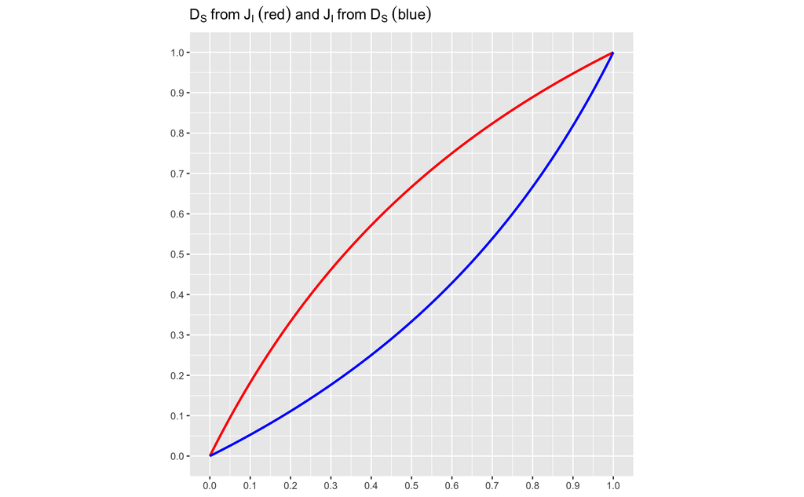

## Dissimilarity: Jaccard Distance (Loss, Bliskość Masek)

In mathematics, a **metric** or **distance function** is a function that defines a distance between each pair of point elements of a set.
$$\begin{align}
\text{J}_\delta(A,B)& {\;\buildrel\rm def\over=\;} 1 - \text{J}_I(A,B) =\\
& = \frac{|A \setminus B \cup B \setminus A|}{|A \cup B|} =\\
& = \frac{|A \bigtriangleup B|}{|A \cup B|}
\end{align}$$
Properties.
$$\begin{align}
\text{J}_\delta(A,B) = 0 \iff A = B&
\quad\text{identity of indiscernibles}\\
\text{J}_\delta(A,B) = \text{J}_\delta(B,A)&
\quad\text{symmetry}\\
\text{J}_\delta(K,M) \leq \text{J}_\delta(K,U) + \text{J}_\delta(U,M)&
\quad\text{triangle inequality}\\
\left|\,\text{J}_\delta(M,U) - \text{J}_\delta(K,U)\,\right| \leq \text{J}_\delta(K,M)\\
\left|\,\text{J}_\delta(K,U) - \text{J}_\delta(K,M)\,\right| \leq \text{J}_\delta(M,U)
\end{align}$$

## Dane

```r
c(underweight, overweight) %<-% rraysplot2::uo_768x384x1
```

## Chudzi

```r
uA <- underweight$km$mask_tensor
uB <- underweight$mp$mask_tensor
```

```r
jaccard_info(uA, uB, tab_header = "Chudzi: SCAT & VSAT")
```

Chudzi: SCAT & VSAT

| patients | SCAT(J_δ) | SCAT(A ∩ B) | SCAT(A ∪ B) | VSAT(J_δ) | VSAT(A ∩ B) | VSAT(A ∪ B) |
| --- | --- | --- | --- | --- | --- | --- |
| 1264707 | 8.66% | 12157 | 13309 | 28.73% | 7928 | 11124 |
| 1487001 | 7.48% | 11973 | 12941 | 20.50% | 6786 | 8536 |
| 1553452 | 12.51% | 6841 | 7819 | 20.95% | 6233 | 7885 |
| 1610908 | 9.41% | 10151 | 11206 | 25.79% | 6563 | 8844 |
| 1667188 | 8.85% | 8484 | 9308 | 30.41% | 3354 | 4820 |
| 1676769-2015 | 3.71% | 7920 | 8225 | 19.42% | 5898 | 7319 |
| 1695380 | 6.16% | 12003 | 12791 | 13.80% | 10789 | 12516 |
| 1762668 | 11.69% | 7383 | 8360 | 23.76% | 5980 | 7844 |
| 1772290 | 0.86% | 18484 | 18645 | 19.78% | 14646 | 18257 |
| 2026715 | 1.73% | 13557 | 13796 | 15.27% | 8809 | 10396 |

## Grubi

```r
oA <- overweight$km$mask_tensor
oB <- overweight$mp$mask_tensor
```

```r
jaccard_info(oA, oB, tab_header = "Grubi: SCAT & VSAT")
```

Grubi: SCAT & VSAT

| patients | SCAT(J_δ) | SCAT(A ∩ B) | SCAT(A ∪ B) | VSAT(J_δ) | VSAT(A ∩ B) | VSAT(A ∪ B) |
| --- | --- | --- | --- | --- | --- | --- |
| 1573415-2019 | 6.33% | 40920 | 43683 | 14.43% | 20605 | 24081 |
| 158894-2018 | 2.01% | 25784 | 26312 | 12.00% | 15586 | 17711 |
| 1678996 | 4.60% | 31938 | 33479 | 11.17% | 19148 | 21555 |
| 1842247 | 5.26% | 21067 | 22236 | 14.97% | 13154 | 15470 |
| 1866633 | 4.93% | 24915 | 26207 | 15.24% | 12328 | 14544 |
| 389728 | 6.22% | 23811 | 25389 | 11.82% | 17253 | 19566 |
| 547766 | 2.29% | 63090 | 64568 | 14.31% | 23483 | 27405 |
| 626604 | 2.01% | 52348 | 53421 | 9.21% | 37208 | 40983 |
| 871006 | 5.04% | 25819 | 27190 | 14.94% | 12033 | 14147 |
| 914522 | 5.32% | 18027 | 19039 | 14.54% | 8896 | 10409 |

## Porównanie *dobrych* masek

### Gruby

```r
compare_masks(
  overweight, patient = "1842247", segment = "SCAT", A = "km", B = "mp"
)
```

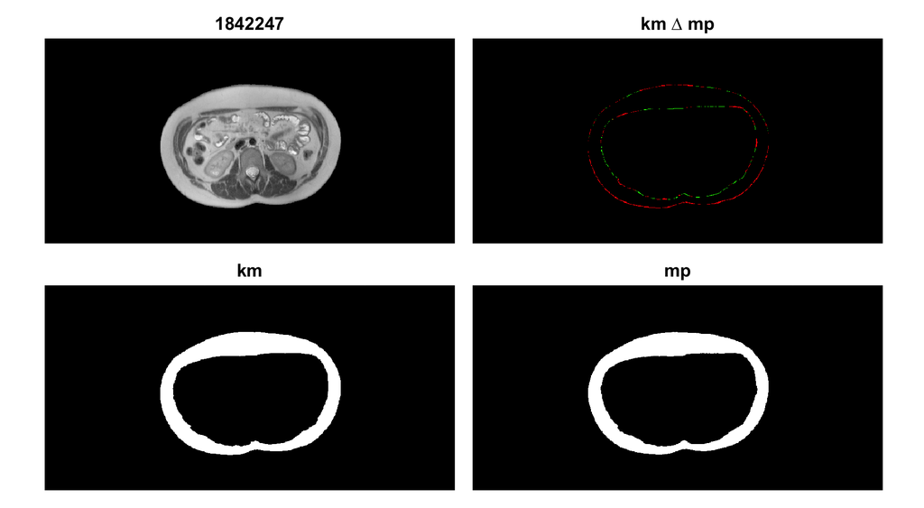

```r
compare_masks(
  overweight, patient = "1842247", segment = "VSAT", A = "km", B = "mp"
)
```

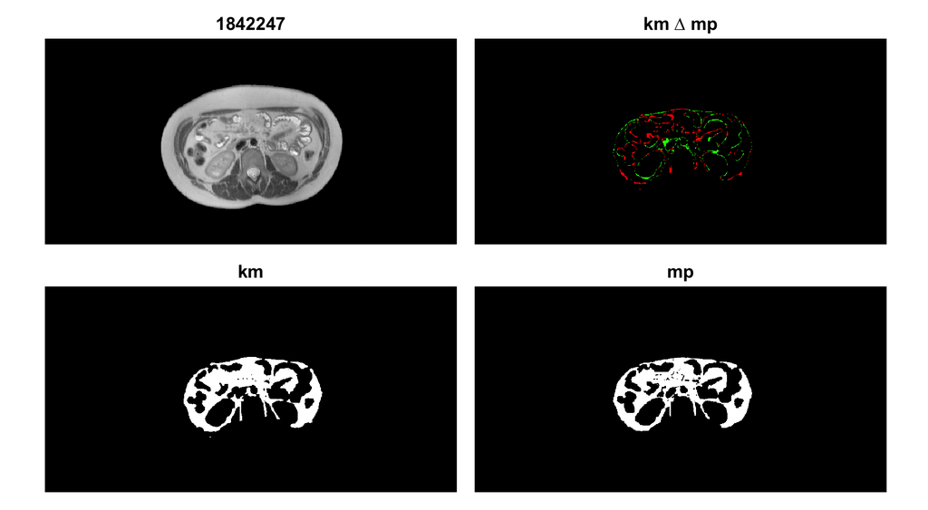

### Chudy

```r
compare_masks(
  underweight, patient = "2026715", segment = "SCAT", A = "km", B = "mp"
)
```

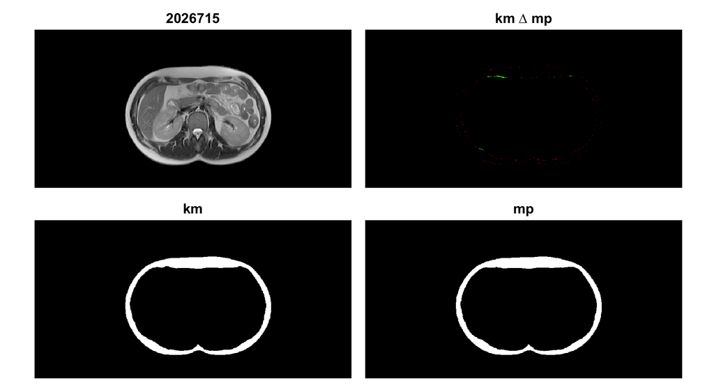

```r
compare_masks(
  underweight, patient = "2026715", segment = "VSAT", A = "km", B = "mp"
)
```

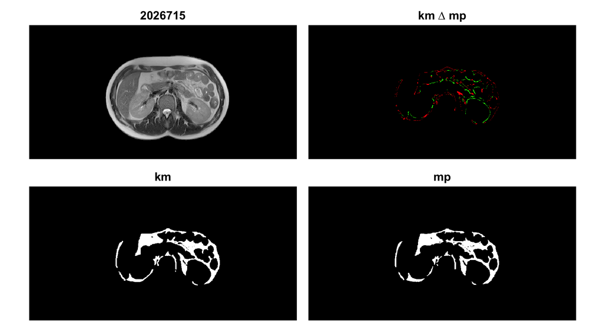

## Porównanie *podejrzanych* masek

### Chudy

```r
compare_masks(
  underweight, patient ="1676769-2015", segment = "SCAT", A = "km", B = "mp"
)
```

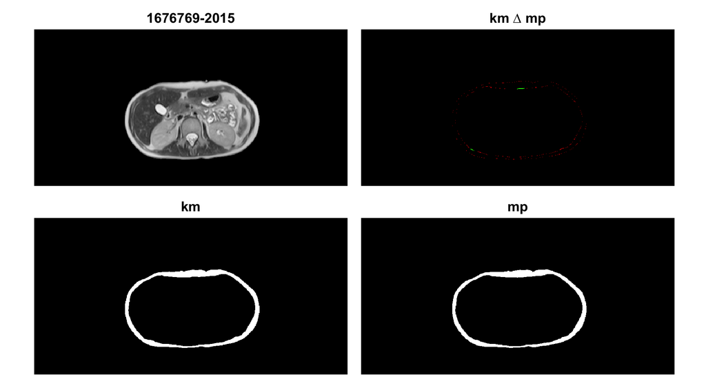

```r
compare_masks(
  underweight, patient ="1676769-2015", segment = "VSAT", A = "km", B = "mp"
)
```

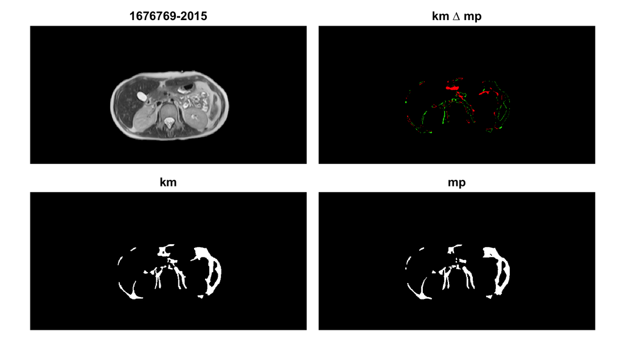

### Gruby

```r
compare_masks(
  overweight, patient = "626604", segment = "SCAT", A = "km", B = "mp"
)
```

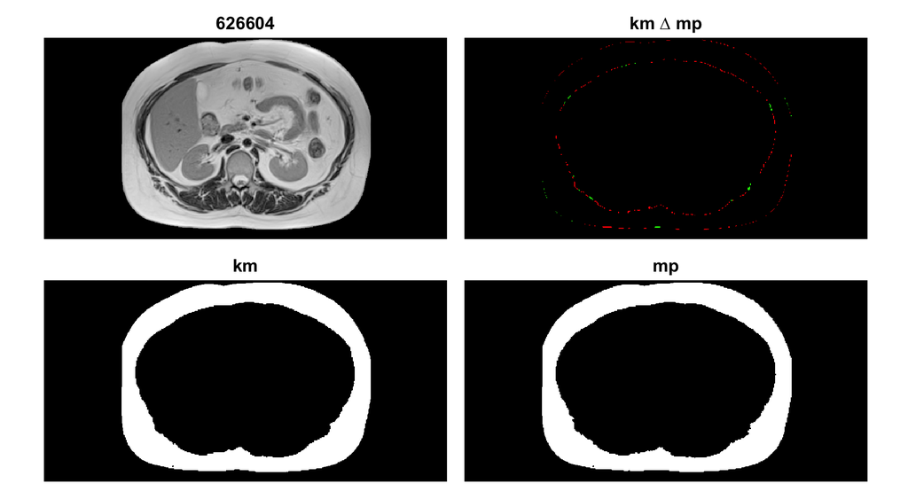

```r
compare_masks(
  overweight, patient = "626604", segment = "VSAT", A = "km", B = "mp"
)
```

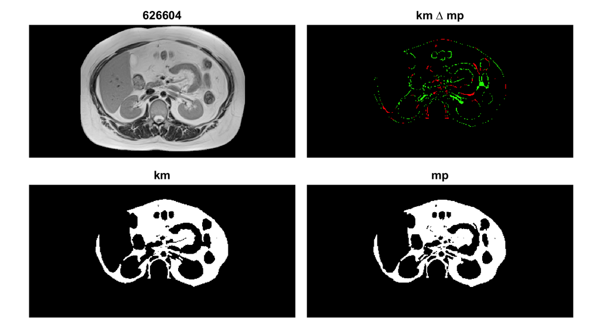